# NOTIFIABLE MEDICAL CONDITIONS SURVEILLANCE SYSTEM

Author

The National Institute for Communicable Diseases

Published

April 2, 2026

# Introduction

Data used in this report was drawn from the NMC-SS on **16 March 2026**. The most recent report should always be viewed and can be found at [NMCSS surveillance reports](https://www.nicd.ac.za/nmc-overview/nmc-monthly-surveillance-report/).

The purpose of this report is to describe the number of notifications received by the Notifiable Medical Conditions Surveillance System (NMCSS). The report is publicly available and can be used by health professionals, researchers, the general public, or any other stakeholder.

Category 4 NMCs, COVID-19, and multi-system inflammatory syndrome (MIS-C) have been excluded from this report. Where weeks are presented, the epiweek according to the CDC epiweeks are used.

## Highlights

Table 1: Highlights of notifications reported to the NMC, in South Africa; January 2022–March, 2026

| 1 | Case Type Clinical notifications N = 4 5482 | Case Type Laboratory notifications N = 9272 | Case Type Merged Cases N = 1122 | Confirmed by Centre Confirmed N = 4051 | Reported by Diagnosis Method Confirmed N = 3 3743 |
| --- | --- | --- | --- | --- | --- |
| NMC Category |  |  |  |  |  |
| Category 1 | 624 (72%) | 160 (18%) | 83 (9.6%) | 371/867 (43%) | 446 (51%) |
| Category 2 | 3 924 (84%) | 718 (15%) | 29 (0.6%) | 34/4 671 (0.7%) | 2 928 (63%) |
| Category 3 | 0 (0%) | 49 (100%) | 0 (0%) | 0/49 (0%) | 0 (0%) |

1n confirmed / N (proportion confirmed %)  
2n (%)  
3n confirmed / N (proportion confirmed %) — by reported diagnosis method

# Category 1 Conditions

Category 1 conditions must be notified within 24 hours of diagnosis. A total of **867** category 1 conditions were notified in March, 2026. The majority were notified with a median (IQR) time to notification of **0 (0, 1)** days.

## NMC Reporting Application

- [NMC Reporting App](https://nmc.nicd.ac.za/Account/Login) is available on both web and mobile platforms.
- Use recommended browsers to access the NMC reporting App for notifications, searching of cases and reports.
- Register if you have no NMC account; you can reset your password if you have not used the application in over 12 months.

## Current Notification Trends

Trends of notifications of selected conditions are presented below.

### Confirmed Notifications

#### Epitable

Table 2: Confirmed notifications of selected category 1 conditions reported to the NMC, in South Africa; January 2022–March, 2026

| Characteristic | Average Notifications | Average Notifications 95% CI | Epiweeks 46 | Epiweeks 47 | Epiweeks 48 | Epiweeks 49 | Epiweeks 50 | Epiweeks 51 | Epiweeks 52 | Epiweeks 53 | Epiweeks 1 | Epiweeks 2 | Epiweeks 3 | Epiweeks 4 | Epiweeks 5 | Epiweeks 6 | Epiweeks 7 | Epiweeks 8 | Epiweeks 9 | Epiweeks 10 | Epiweeks 11 | Epiweeks 12 | Epiweeks 13 |
| --- | --- | --- | --- | --- | --- | --- | --- | --- | --- | --- | --- | --- | --- | --- | --- | --- | --- | --- | --- | --- | --- | --- | --- |
| Acute flaccid paralysis | 0.10 | 1.0, 2.0 | 0 | 0 | 0 | 0 | 0 | 0 | 0 | 0 | 0 | 0 | 0 | 0 | 0 | 0 | 0 | 0 | 0 | 0 | 0 | 0 | 0 |
| Acute rheumatic fever | 0.0261 | 1.0, 1.0 | 0 | 0 | 0 | 0 | 0 | 1 | 0 | 0 | 0 | 1 | 0 | 0 | 0 | 0 | 0 | 0 | 0 | 0 | 0 | 0 | 0 |
| Agricultural or stock remedy poisoning | 0.10 | 1.0, 1.5 | 0 | 0 | 0 | 0 | 0 | 0 | 0 | 0 | 0 | 0 | 0 | 0 | 0 | 0 | 0 | 0 | 0 | 0 | 0 | 0 | 0 |
| Botulism | 0.0056 | NA, NA | 0 | 0 | 0 | 0 | 0 | 0 | 0 | 0 | 0 | 0 | 0 | 0 | 0 | 0 | 0 | 0 | 0 | 0 | 0 | 0 | 0 |
| Cholera | 0.50 | 1.5, 2.0 | 0 | 0 | 0 | 0 | 0 | 0 | 0 | 0 | 0 | 0 | 0 | 0 | 0 | 0 | 0 | 0 | 0 | 0 | 0 | 0 | 0 |
| Congenital rubella syndrome | 0.0112 | NA, NA | 0 | 0 | 0 | 0 | 0 | 0 | 0 | 0 | 0 | 0 | 0 | 0 | 0 | 0 | 0 | 0 | 0 | 0 | 0 | 0 | 0 |
| Covid-19 | 177 | 13, 48 | 0 | 0 | 0 | 0 | 0 | 0 | 0 | 0 | 0 | 0 | 0 | 0 | 0 | 0 | 0 | 0 | 0 | 0 | 0 | 0 | 0 |
| Crimean-congo viral haemorrhagic fever (human) | 0.0280 | 1.0, 1.0 | 0 | 0 | 0 | 0 | 0 | 0 | 0 | 0 | 0 | 0 | 0 | 0 | 0 | 0 | 0 | 0 | 0 | 0 | 0 | 0 | 0 |
| Diphtheria | 0.25 | 1.0, 1.5 | 0 | 0 | 0 | 1 | 3 | 0 | 0 | 1 | 2 | 1 | 1 | 1 | 0 | 0 | 0 | 1 | 0 | 1 | 0 | 0 | 0 |
| Enteric fever (typhoid or paratyphoid fever) | 1.19 | 2.0, 2.0 | 5 | 4 | 4 | 7 | 5 | 1 | 1 | 2 | 0 | 3 | 5 | 3 | 2 | 2 | 4 | 6 | 4 | 2 | 0 | 0 | 0 |
| Food borne illness outbreak | 0.0616 | 1.0, 2.0 | 0 | 0 | 0 | 0 | 0 | 0 | 0 | 0 | 0 | 0 | 0 | 0 | 0 | 0 | 0 | 0 | 0 | 0 | 0 | 0 | 0 |
| Listeriosis | 1.15 | 1.5, 1.5 | 1 | 1 | 1 | 0 | 1 | 1 | 1 | 0 | 0 | 0 | 1 | 3 | 1 | 1 | 0 | 1 | 1 | 0 | 0 | 0 | 0 |
| Malaria | 144 | 97, 116 | 35 | 38 | 40 | 35 | 50 | 68 | 55 | 145 | 176 | 301 | 306 | 219 | 192 | 237 | 233 | 198 | 142 | 139 | 24 | 0 | 0 |
| Measles | 3.5 | 3.5, 5.5 | 30 | 52 | 66 | 73 | 64 | 39 | 33 | 34 | 32 | 23 | 18 | 20 | 28 | 27 | 32 | 35 | 27 | 10 | 0 | 0 | 0 |
| Meningococcal disease | 1.01 | 2.0, 2.0 | 1 | 2 | 3 | 4 | 0 | 1 | 2 | 2 | 3 | 3 | 2 | 0 | 3 | 3 | 5 | 2 | 1 | 2 | 0 | 0 | 0 |
| Mpox | 0.0746 | 1.0, 2.0 | 0 | 0 | 0 | 1 | 1 | 1 | 0 | 0 | 1 | 0 | 1 | 0 | 0 | 0 | 0 | 0 | 0 | 0 | 0 | 0 | 0 |
| Pertussis | 8 | 10, 13 | 16 | 24 | 14 | 15 | 10 | 20 | 14 | 24 | 27 | 30 | 28 | 24 | 13 | 13 | 29 | 19 | 17 | 8 | 0 | 0 | 0 |
| Rabies | 0.10 | 1.0, 1.0 | 0 | 0 | 0 | 0 | 0 | 0 | 0 | 0 | 1 | 0 | 0 | 1 | 0 | 0 | 0 | 1 | 0 | 1 | 0 | 0 | 0 |
| Respiratory disease caused by a novel respiratory pathogen | 0.0037 | NA, NA | 0 | 0 | 0 | 0 | 0 | 0 | 0 | 0 | 0 | 0 | 0 | 0 | 0 | 0 | 0 | 0 | 0 | 0 | 0 | 0 | 0 |
| Rift valley fever (human) | 0.0112 | 1.0, 1.0 | 0 | 0 | 0 | 0 | 0 | 0 | 0 | 0 | 0 | 0 | 0 | 0 | 0 | 0 | 0 | 0 | 0 | 0 | 0 | 0 | 0 |
| Rubella | 1.36 | 2.5, 3.5 | 5 | 4 | 12 | 5 | 7 | 3 | 1 | 2 | 4 | 2 | 1 | 2 | 3 | 2 | 1 | 2 | 1 | 0 | 0 | 0 | 0 |

Abbreviation: CI = Confidence Interval

#### Trends Plot

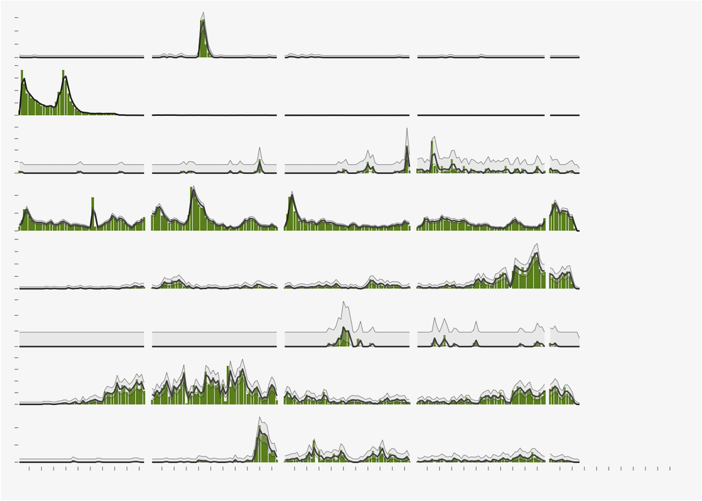

Figure 1: Trend of weekly confirmed notifications for selected category 1 conditions, South Africa; January 2022–March, 2026

## All Category 1 Conditions at a Glance

Table 3: Confirmed notifications (by diagnosis method) for category 1 conditions notified during March, 2026

| Characteristic | Category 11 |
| --- | --- |
| Acute flaccid paralysis | 1/7 (14)% |
| Acute rheumatic fever | 0/0 (NA)% |
| Agricultural or stock remedy poisoning | 9/48 (19)% |
| Anthrax | 0/0 (NA)% |
| Botulism | 0/0 (NA)% |
| Cholera | 0/0 (NA)% |
| Congenital rubella syndrome | 2/6 (33)% |
| Covid-19 | 0/0 (NA)% |
| Crimean-congo viral haemorrhagic fever (human) | 0/0 (NA)% |
| Diphtheria | 3/8 (38)% |
| Ebola virus (VHF) | 0/0 (NA)% |
| Enteric fever (typhoid or paratyphoid fever) | 9/15 (60)% |
| Food borne illness outbreak | 1/50 (2.0)% |
| Haemolytic uraemic syndrome (HUS) | 0/0 (NA)% |
| Listeriosis | 2/3 (67)% |
| Malaria | 296/296 (100)% |
| Marburg virus (VHF) | 0/0 (NA)% |
| Measles | 68/338 (20)% |
| Meningococcal disease | 4/8 (50)% |
| Mpox | 0/0 (NA)% |
| Pertussis | 49/53 (92)% |
| Plague | 0/0 (NA)% |
| Poliomyelitis | 0/0 (NA)% |
| Rabies | 1/3 (33)% |
| Respiratory disease caused by a novel respiratory pathogen | 0/0 (NA)% |
| Rift valley fever (human) | 0/0 (NA)% |
| Rubella | 1/32 (3.1)% |
| Smallpox | 0/0 (NA)% |
| Yellow fever | 0/0 (NA)% |

1n confirmed / N notified (proportion confirmed %)

# NMC Data Summary, March, 2026

In March, 2026 the NMCSS received a total of **5 587** notifications. Of these, 867 (16%) were Category 1 notifications, 4 671 (84%) were Category 2, and 49 (0.9%) were Category 3.

## Category 1 Notifications

The most commonly notified category 1 condition was **Measles** (338 (39%)).

Table 4: Category 1 notifications by province, South Africa; March, 2026

| Category 1 Condition | Overall, n = 867 (100%)1 | EC, n = 37 (4.3%)1 | FS, n = 31 (3.6%)1 | GP, n = 158 (18%)1 | KZN, n = 136 (16%)1 | LP, n = 106 (12%)1 | MP, n = 130 (15%)1 | NC, n = 36 (4.2%)1 | NW, n = 14 (1.6%)1 | WC, n = 219 (25%)1 |
| --- | --- | --- | --- | --- | --- | --- | --- | --- | --- | --- |
| Acute flaccid paralysis | 7 (100%) | 0 (0%) | 0 (0%) | 5 (71%) | 2 (29%) | 0 (0%) | 0 (0%) | 0 (0%) | 0 (0%) | 0 (0%) |
| Agricultural or stock remedy poisoning | 48 (100%) | 3 (6.3%) | 11 (23%) | 22 (46%) | 1 (2.1%) | 5 (10%) | 2 (4.2%) | 0 (0%) | 1 (2.1%) | 3 (6.3%) |
| Congenital rubella syndrome | 6 (100%) | 0 (0%) | 0 (0%) | 1 (17%) | 3 (50%) | 0 (0%) | 1 (17%) | 1 (17%) | 0 (0%) | 0 (0%) |
| Diphtheria | 8 (100%) | 0 (0%) | 0 (0%) | 0 (0%) | 2 (25%) | 1 (13%) | 0 (0%) | 0 (0%) | 0 (0%) | 5 (63%) |
| Enteric fever (typhoid or paratyphoid fever) | 15 (100%) | 0 (0%) | 0 (0%) | 9 (60%) | 0 (0%) | 0 (0%) | 5 (33%) | 0 (0%) | 0 (0%) | 1 (6.7%) |
| Food borne illness outbreak | 50 (100%) | 7 (14%) | 3 (6.0%) | 15 (30%) | 7 (14%) | 0 (0%) | 13 (26%) | 0 (0%) | 0 (0%) | 5 (10%) |
| Listeriosis | 3 (100%) | 0 (0%) | 0 (0%) | 2 (67%) | 1 (33%) | 0 (0%) | 0 (0%) | 0 (0%) | 0 (0%) | 0 (0%) |
| Malaria | 296 (100%) | 5 (1.7%) | 3 (1.0%) | 47 (16%) | 86 (29%) | 70 (24%) | 75 (25%) | 1 (0.3%) | 4 (1.4%) | 5 (1.7%) |
| Measles | 338 (100%) | 17 (5.0%) | 9 (2.7%) | 25 (7.4%) | 20 (5.9%) | 24 (7.1%) | 27 (8.0%) | 30 (8.9%) | 4 (1.2%) | 182 (54%) |
| Meningococcal disease | 8 (100%) | 1 (13%) | 0 (0%) | 0 (0%) | 1 (13%) | 1 (13%) | 0 (0%) | 0 (0%) | 0 (0%) | 5 (63%) |
| Pertussis | 53 (100%) | 0 (0%) | 2 (3.8%) | 26 (49%) | 9 (17%) | 1 (1.9%) | 4 (7.5%) | 1 (1.9%) | 2 (3.8%) | 8 (15%) |
| Rabies | 3 (100%) | 0 (0%) | 0 (0%) | 2 (67%) | 1 (33%) | 0 (0%) | 0 (0%) | 0 (0%) | 0 (0%) | 0 (0%) |
| Rubella | 32 (100%) | 4 (13%) | 3 (9.4%) | 4 (13%) | 3 (9.4%) | 4 (13%) | 3 (9.4%) | 3 (9.4%) | 3 (9.4%) | 5 (16%) |

1n (%)

## Category 2 Notifications

Category 2 conditions must be notified within 7 days of diagnosis.

The most common Category 2 condition was **Tuberculosis:pulmonary** (3 043 (65%)).

Table 5: Category 2 notifications by province, South Africa; March, 2026

| Category 2 Condition | Overall, n = 4 671 (100%)1 | EC, n = 439 (9.4%)1 | FS, n = 193 (4.1%)1 | GP, n = 1 066 (23%)1 | KZN, n = 1 227 (26%)1 | LP, n = 244 (5.2%)1 | MP, n = 201 (4.3%)1 | NC, n = 253 (5.4%)1 | NW, n = 185 (4.0%)1 | WC, n = 863 (18%)1 |
| --- | --- | --- | --- | --- | --- | --- | --- | --- | --- | --- |
| Bilharzia (schistosomiasis) | 277 (5.9%) | 14 (3.2%) | 0 (0%) | 6 (0.6%) | 126 (10%) | 78 (32%) | 39 (19%) | 0 (0%) | 2 (1.1%) | 12 (1.4%) |
| Brucellosis | 2 (<0.1%) | 0 (0%) | 0 (0%) | 1 (<0.1%) | 0 (0%) | 0 (0%) | 0 (0%) | 0 (0%) | 1 (0.5%) | 0 (0%) |
| Congenital syphilis | 142 (3.0%) | 15 (3.4%) | 7 (3.6%) | 29 (2.7%) | 47 (3.8%) | 4 (1.6%) | 3 (1.5%) | 6 (2.4%) | 0 (0%) | 31 (3.6%) |
| Haemophilus influenzae type B | 4 (<0.1%) | 0 (0%) | 0 (0%) | 2 (0.2%) | 0 (0%) | 1 (0.4%) | 0 (0%) | 0 (0%) | 0 (0%) | 1 (0.1%) |
| Hepatitis A | 78 (1.7%) | 3 (0.7%) | 8 (4.1%) | 18 (1.7%) | 11 (0.9%) | 7 (2.9%) | 6 (3.0%) | 5 (2.0%) | 4 (2.2%) | 16 (1.9%) |
| Hepatitis B | 409 (8.8%) | 47 (11%) | 13 (6.7%) | 41 (3.8%) | 257 (21%) | 3 (1.2%) | 10 (5.0%) | 18 (7.1%) | 14 (7.6%) | 6 (0.7%) |
| Hepatitis C | 13 (0.3%) | 0 (0%) | 0 (0%) | 5 (0.5%) | 3 (0.2%) | 0 (0%) | 3 (1.5%) | 0 (0%) | 1 (0.5%) | 1 (0.1%) |
| Hepatitis E | 1 (<0.1%) | 0 (0%) | 0 (0%) | 0 (0%) | 0 (0%) | 0 (0%) | 0 (0%) | 1 (0.4%) | 0 (0%) | 0 (0%) |
| Lead poisoning | 0 (0%) | 0 (0%) | 0 (0%) | 0 (0%) | 0 (0%) | 0 (0%) | 0 (0%) | 0 (0%) | 0 (0%) | 0 (0%) |
| Legionellosis | 9 (0.2%) | 2 (0.5%) | 0 (0%) | 3 (0.3%) | 1 (<0.1%) | 0 (0%) | 1 (0.5%) | 0 (0%) | 2 (1.1%) | 0 (0%) |
| Leprosy | 0 (0%) | 0 (0%) | 0 (0%) | 0 (0%) | 0 (0%) | 0 (0%) | 0 (0%) | 0 (0%) | 0 (0%) | 0 (0%) |
| Maternal death (pregnancy, childbirth and puerperium) | 6 (0.1%) | 0 (0%) | 0 (0%) | 2 (0.2%) | 0 (0%) | 3 (1.2%) | 1 (0.5%) | 0 (0%) | 0 (0%) | 0 (0%) |
| Mercury poisoning | 0 (0%) | 0 (0%) | 0 (0%) | 0 (0%) | 0 (0%) | 0 (0%) | 0 (0%) | 0 (0%) | 0 (0%) | 0 (0%) |
| Soil transmitted helminths | 0 (0%) | 0 (0%) | 0 (0%) | 0 (0%) | 0 (0%) | 0 (0%) | 0 (0%) | 0 (0%) | 0 (0%) | 0 (0%) |
| Tetanus | 0 (0%) | 0 (0%) | 0 (0%) | 0 (0%) | 0 (0%) | 0 (0%) | 0 (0%) | 0 (0%) | 0 (0%) | 0 (0%) |
| Tuberculosis: extensively drug -resistant (XDR -TB)* | 1 (<0.1%) | 0 (0%) | 0 (0%) | 1 (<0.1%) | 0 (0%) | 0 (0%) | 0 (0%) | 0 (0%) | 0 (0%) | 0 (0%) |
| Tuberculosis: multidrug- resistant (MDR -TB)* | 88 (1.9%) | 7 (1.6%) | 6 (3.1%) | 28 (2.6%) | 23 (1.9%) | 1 (0.4%) | 1 (0.5%) | 4 (1.6%) | 0 (0%) | 18 (2.1%) |
| Tuberculosis:extra-pulmonary* | 598 (13%) | 61 (14%) | 17 (8.8%) | 231 (22%) | 116 (9.5%) | 24 (9.8%) | 19 (9.5%) | 23 (9.1%) | 22 (12%) | 85 (9.8%) |
| Tuberculosis:pulmonary* | 3 043 (65%) | 290 (66%) | 142 (74%) | 699 (66%) | 643 (52%) | 123 (50%) | 118 (59%) | 196 (77%) | 139 (75%) | 693 (80%) |

1n (%)

# NMC App Statistics

## Notification Types and Merging

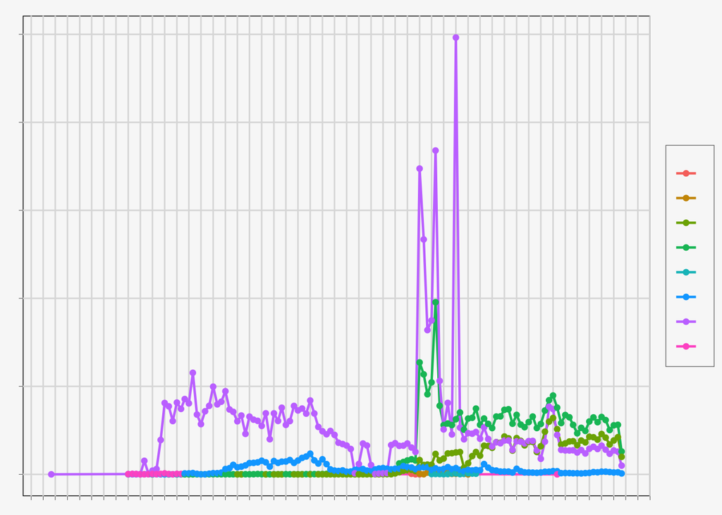

Figure 2: Notification source trends, South Africa; January 2022–March, 2026

# Data Quality

## Completeness

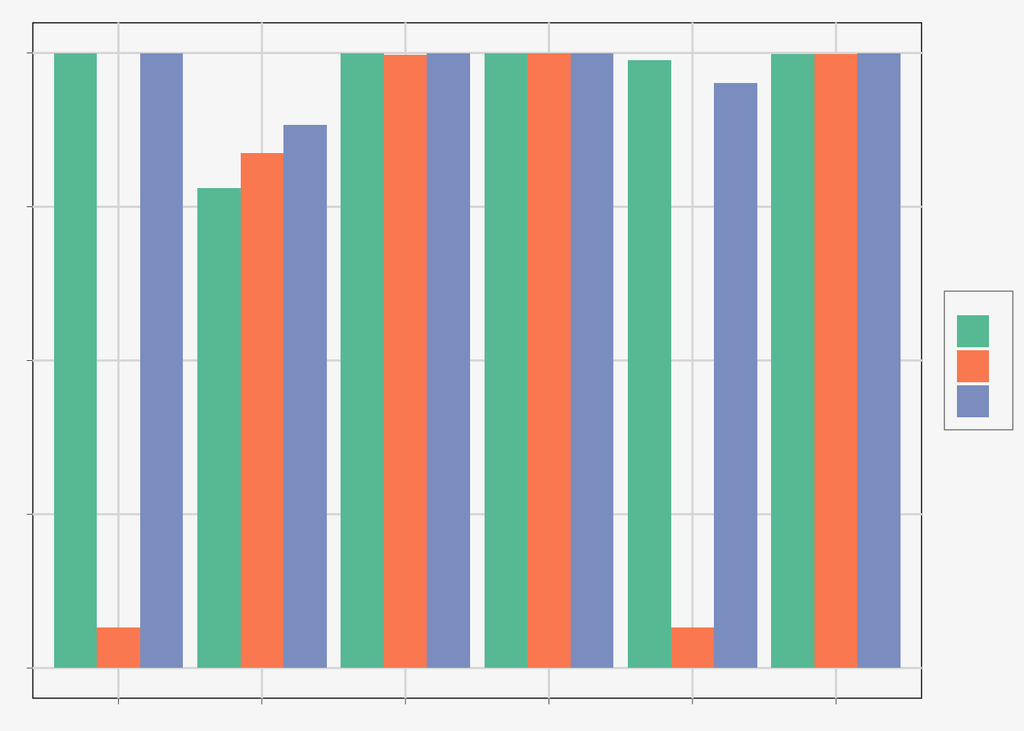

Figure 3: Completeness of key variables by notification source, March, 2026

## ID Number Completeness

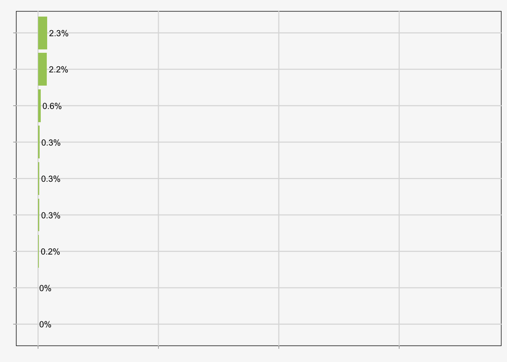

Figure 4: ID number completeness by province, March, 2026

## Timeliness

Table 6: Timeliness of notifications (days from diagnosis to notification), March, 2026

| Characteristic | Category 1 N = 867 | Category 2 N = 4 671 | Category 3 N = 49 |
| --- | --- | --- | --- |
| Days to notification | 0 (0, 1) | 1 (0, 9) | 0 (0, 0) |

# Conclusion

The majority of notifications were clinical notifications. Patients who are hospitalised with a category 1 condition and notified still have poor completeness of the hospital form, with the majority of notifications only having symptoms completed. ID numbers are poorly completed in notifications from SDW.

# Recommendations

- We recommend that clinicians complete all patient clinical and demographic details to improve hospital form completeness.
- We strongly recommend complete ID number capture in the SDW system to improve data quality and the ability for the NMCSS to merge clinical and laboratory notifications.
- Feedback and suggestions are welcome at **brianb@nicd.ac.za** and **matimbam@nicd.ac.za**.

# Appendices

## Appendix 1: Back-Captured Clinical Notifications

Table 7: Back-captured and delayed notifications by condition and case source, March, 2026

|  | Android, (5) | iOS, (10) | SDW, (1) | Web, (79) |
| --- | --- | --- | --- | --- |
| Measles | 3 | 5 | 0 | 63 |
| Agricultural or stock remedy poisoning | 1 | 0 | 0 | 8 |
| Malaria | 1 | 5 | 1 | 2 |
| Pertussis | 0 | 0 | 0 | 3 |
| Rubella | 0 | 0 | 0 | 3 |

## Appendix 2: Summary of NMCSS Data Flow

The NMCSS receives notifications from:

1. **NMC App** — web, iOS, Android (clinical and laboratory notifications)
2. **Paper forms** — submitted by facilities and captured into the system
3. **SDW/Microstrategy** — laboratory notifications drawn from the NHLS system

Notifications are merged where clinical and laboratory notifications relate to the same case.

## Appendix 3: NMC Categories and Case Classification

| Category | Notification period | Description |
| --- | --- | --- |
| Category 1 | Within 24 hours | Immediately notifiable; notify on clinical suspicion |
| Category 2 | Within 7 days | Routine surveillance; notify after diagnosis |
| Category 3 | Within 7 days | Outbreak-prone; aggregate reporting |
| Category 4 | Excluded from this report |  |

## Appendix 4: Full Category 1 Epitable (2022–March, 2026)

Table 8: All notifications of category 1 conditions, South Africa; January 2022–March, 2026

| Characteristic | Average Notifications | Average Notifications 95% CI | Epiweeks 46 | Epiweeks 47 | Epiweeks 48 | Epiweeks 49 | Epiweeks 50 | Epiweeks 51 | Epiweeks 52 | Epiweeks 53 | Epiweeks 1 | Epiweeks 2 | Epiweeks 3 | Epiweeks 4 | Epiweeks 5 | Epiweeks 6 | Epiweeks 7 | Epiweeks 8 | Epiweeks 9 | Epiweeks 10 | Epiweeks 11 | Epiweeks 12 | Epiweeks 13 |
| --- | --- | --- | --- | --- | --- | --- | --- | --- | --- | --- | --- | --- | --- | --- | --- | --- | --- | --- | --- | --- | --- | --- | --- |
| Acute flaccid paralysis | 3.9 | 4.5, 5.0 | 3 | 9 | 6 | 4 | 4 | 4 | 4 | 5 | 6 | 8 | 5 | 5 | 5 | 10 | 9 | 2 | 3 | 4 | 0 | 0 | 0 |
| Acute rheumatic fever | 0.23 | 1.0, 1.0 | 1 | 0 | 0 | 0 | 3 | 1 | 0 | 1 | 1 | 1 | 1 | 0 | 0 | 1 | 0 | 0 | 0 | 0 | 0 | 0 | 0 |
| Agricultural or stock remedy poisoning | 12 | 13, 15 | 21 | 30 | 43 | 26 | 37 | 25 | 16 | 19 | 31 | 19 | 27 | 32 | 39 | 28 | 13 | 43 | 37 | 17 | 3 | 0 | 0 |
| Anthrax | 0.0093 | NA, NA | 0 | 0 | 0 | 0 | 0 | 0 | 0 | 1 | 0 | 0 | 0 | 0 | 0 | 0 | 0 | 0 | 0 | 0 | 0 | 0 | 0 |
| Botulism | 0.0466 | 1.0, 1.0 | 0 | 0 | 0 | 0 | 0 | 0 | 0 | 0 | 0 | 0 | 1 | 0 | 0 | 0 | 0 | 0 | 0 | 0 | 0 | 0 | 0 |
| Cholera | 2.94 | 1.5, 3.0 | 0 | 0 | 0 | 0 | 2 | 1 | 0 | 1 | 0 | 0 | 0 | 0 | 0 | 0 | 1 | 1 | 0 | 0 | 0 | 0 | 0 |
| Congenital rubella syndrome | 2.47 | 2.5, 3.0 | 4 | 3 | 3 | 1 | 2 | 6 | 1 | 4 | 3 | 1 | 3 | 3 | 2 | 0 | 1 | 3 | 5 | 1 | 0 | 0 | 0 |
| Covid-19 | 532 | 331, 500 | 0 | 0 | 0 | 0 | 0 | 0 | 0 | 0 | 0 | 0 | 0 | 0 | 0 | 0 | 0 | 0 | 0 | 0 | 0 | 0 | 0 |
| Crimean-congo viral haemorrhagic fever (human) | 0.23 | 1.0, 1.5 | 0 | 0 | 1 | 0 | 0 | 0 | 0 | 0 | 0 | 0 | 0 | 1 | 0 | 0 | 0 | 0 | 0 | 0 | 0 | 0 | 0 |
| Diphtheria | 1.45 | 2.5, 3.0 | 4 | 1 | 0 | 9 | 10 | 2 | 4 | 3 | 5 | 6 | 4 | 5 | 7 | 4 | 3 | 3 | 4 | 3 | 1 | 0 | 0 |
| Ebola virus (VHF) | 0.0317 | 1.0, 1.0 | 0 | 0 | 0 | 0 | 0 | 0 | 0 | 0 | 0 | 0 | 0 | 0 | 0 | 0 | 0 | 0 | 0 | 0 | 0 | 0 | 0 |
| Enteric fever (typhoid or paratyphoid fever) | 2.98 | 3.5, 4.0 | 15 | 6 | 8 | 13 | 9 | 1 | 3 | 5 | 5 | 6 | 8 | 9 | 9 | 6 | 11 | 10 | 9 | 6 | 0 | 0 | 0 |
| Food borne illness outbreak | 10 | 9.0, 11 | 1 | 10 | 12 | 6 | 11 | 6 | 2 | 8 | 12 | 6 | 5 | 36 | 16 | 32 | 20 | 18 | 32 | 18 | 0 | 0 | 0 |
| Haemolytic uraemic syndrome (HUS) | 0.0429 | 1.0, 1.0 | 0 | 0 | 0 | 0 | 0 | 0 | 0 | 0 | 0 | 0 | 0 | 0 | 0 | 0 | 0 | 0 | 0 | 0 | 0 | 0 | 0 |
| Listeriosis | 3.4 | 2.5, 3.0 | 2 | 2 | 4 | 3 | 2 | 1 | 2 | 0 | 0 | 1 | 2 | 4 | 1 | 1 | 0 | 1 | 2 | 1 | 0 | 0 | 0 |
| Malaria | 144 | 97, 116 | 35 | 38 | 40 | 35 | 50 | 68 | 55 | 145 | 176 | 301 | 306 | 219 | 192 | 237 | 233 | 198 | 142 | 139 | 24 | 0 | 0 |
| Marburg virus (VHF) | 0.0317 | 1.0, 1.0 | 0 | 0 | 0 | 0 | 0 | 0 | 0 | 0 | 1 | 0 | 0 | 0 | 0 | 0 | 0 | 0 | 0 | 0 | 0 | 0 | 0 |
| Measles | 51 | 26, 36 | 276 | 394 | 385 | 388 | 294 | 197 | 164 | 141 | 153 | 152 | 80 | 109 | 194 | 151 | 178 | 232 | 182 | 208 | 19 | 0 | 0 |
| Meningococcal disease | 2.76 | 3.0, 3.5 | 3 | 5 | 3 | 7 | 4 | 1 | 2 | 2 | 6 | 4 | 2 | 4 | 4 | 5 | 5 | 3 | 3 | 5 | 0 | 0 | 0 |
| Mpox | 0.84 | 2.5, 4.5 | 1 | 1 | 1 | 2 | 4 | 2 | 3 | 2 | 1 | 1 | 1 | 2 | 1 | 0 | 1 | 3 | 0 | 0 | 0 | 0 | 0 |
| Pertussis | 14 | 13, 17 | 28 | 34 | 24 | 30 | 24 | 25 | 21 | 28 | 38 | 35 | 38 | 33 | 21 | 25 | 37 | 26 | 31 | 16 | 9 | 0 | 0 |
| Plague | 0.0019 | NA, NA | 0 | 0 | 0 | 0 | 0 | 0 | 0 | 0 | 0 | 0 | 0 | 0 | 0 | 0 | 0 | 0 | 0 | 0 | 0 | 0 | 0 |
| Poliomyelitis | 0.0224 | NA, NA | 0 | 0 | 0 | 0 | 0 | 0 | 0 | 0 | 0 | 0 | 0 | 0 | 0 | 0 | 0 | 0 | 0 | 0 | 0 | 0 | 0 |
| Rabies | 0.64 | 1.5, 1.5 | 0 | 0 | 0 | 0 | 0 | 0 | 0 | 0 | 2 | 2 | 1 | 1 | 1 | 1 | 3 | 3 | 1 | 2 | 0 | 0 | 0 |
| Respiratory disease caused by a novel respiratory pathogen | 3.8 | 2.5, 7.0 | 0 | 0 | 0 | 0 | 0 | 1 | 1 | 1 | 0 | 0 | 0 | 0 | 0 | 0 | 0 | 0 | 0 | 0 | 0 | 0 | 0 |
| Rift valley fever (human) | 0.07 | 1.0, 1.0 | 0 | 0 | 1 | 0 | 0 | 0 | 0 | 0 | 0 | 0 | 0 | 0 | 0 | 0 | 0 | 0 | 0 | 0 | 0 | 0 | 0 |
| Rubella | 36 | 6.5, 9.0 | 77 | 101 | 91 | 61 | 56 | 24 | 15 | 15 | 14 | 13 | 10 | 11 | 31 | 19 | 21 | 38 | 27 | 8 | 0 | 0 | 0 |
| Smallpox | 0.0392 | 1.0, 2.0 | 0 | 0 | 0 | 0 | 0 | 0 | 0 | 0 | 0 | 0 | 0 | 0 | 0 | 0 | 0 | 0 | 0 | 0 | 0 | 0 | 0 |
| Waterborne illness outbreak - undefined | 0.08 | 1.0, 1.5 | 0 | 0 | 0 | 0 | 0 | 0 | 0 | 0 | 0 | 0 | 0 | 0 | 0 | 0 | 0 | 0 | 0 | 0 | 0 | 0 | 0 |
| Yellow fever | 0.0261 | 1.0, 1.5 | 0 | 0 | 0 | 0 | 0 | 0 | 0 | 0 | 0 | 0 | 0 | 0 | 0 | 0 | 0 | 0 | 0 | 0 | 0 | 0 | 0 |

Abbreviation: CI = Confidence Interval